# Phys474_S23_Hwk4

Physics 474 - Spring 2023

Homework 4 - Solving PDE and ODE boundary value problems with the relaxation method

Using the Gauss-Seidel overrelaxation method

Author: Dillon Walton

In this problem we will solving for the electric potential $\phi(\vec{r})$ and electric field $\vec{E}(x,y)$ in a cylindrical configuration, similar to a coax cable, with fixed voltages on the inner conductor and outer conductor. See figure.

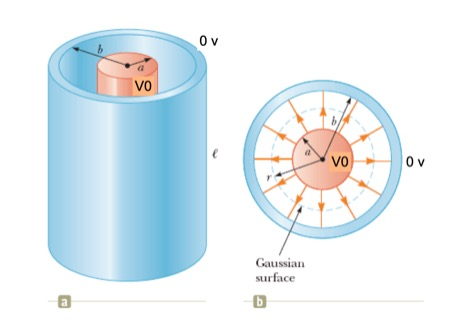

Part a: (10 points)

Poisson's equation in 2-D for electric potential $\phi$ in empty space with boundry conditions.

$\nabla^2 \phi(x,y) = 0$

or,

$\frac{\partial^2 \phi(x,y)}{\partial x ^2}+\frac{\partial^2 \phi(x,y)}{\partial y ^2}=0$

From our lecture we saw that we can use a space-centered finite difference method with grid spacing $a$ for second partial derivatives that yields the approximation

$\Large \nabla^2 \phi(x,y)\approx \frac{\phi(x+a,t)+\phi(x-a,t)-2\phi(x,t)}{a^2} + \frac{\phi(y+a,t)+\phi(y-a,t)-2\phi(y,t)}{a^2}$

Setting this equal to zero for the Poisson equation we get

$\phi(x+a,y)+\phi(x-a,y)+\phi(x,y+a)+\phi(x,y-a)-4\phi(x,y)=0$

or

$\phi(x,y) = \frac{1}{4}\left[\phi(x+a,y)+\phi(x-a,y)+\phi(x,y+a)+\phi(x,y-a)\right]$

These are a set of $n \times n$ simulataneous which could be solved holding the boundary boints at their fixed values.

we will use an iterative method that we call **The Relaxation Method** to solve this set of equations

We will use the **Gauss-Seidel overrelaxation method (see lecture and examples)**

- Fix $\phi(x,y)$ at boundaries for every iteration
- guess some initial values for $\phi(x,y)$
- apply GS-Overrelaxation equation with weight $w<1.0$ to update values on all grid points $\phi(x,y) \leftarrow \frac{(1+w)}{4}\left[\phi(x+a,y)+\phi(x-a,y)+\phi(x,y+a)+\phi(x,y-a)\right]-w \phi(x,y)$
- NOTE: The array on the left is the same as on the right in the implementation, that is the Gauss-Seidel part.
- take these new values and feed them back into right hand side
- Calculate another new set of values, again and again and …
- Until $\phi(x,y)$ settles down (i.e. relaxes) to a fixed value. That is the solution!

The parameters of the coax are:

- radius of the inner conductor is $a = 1\,mm$
- radius of the outer conductor is $b = 6\,mm$
- electric potential (i.e. voltage) on the inner conductor is $V0 = 100 \, v$
- electric potential on the outer conductor is $0 \, v$

for the Gauss-Seidel overrelaxation method use:

- overrelaxation weighting factor $w=0.92$
- termination when max difference between iterations is 1e-8 or iterations = 2500
- pick a 2D grid from $-0.007$ mm to $+0.007$ mm for both $x,y$
- use (2n+1)x(2n+1) grid points so the center point is at 0 and it is symmetric on either side (start with n=50)
- investigate different n (maybe 25 and 100)

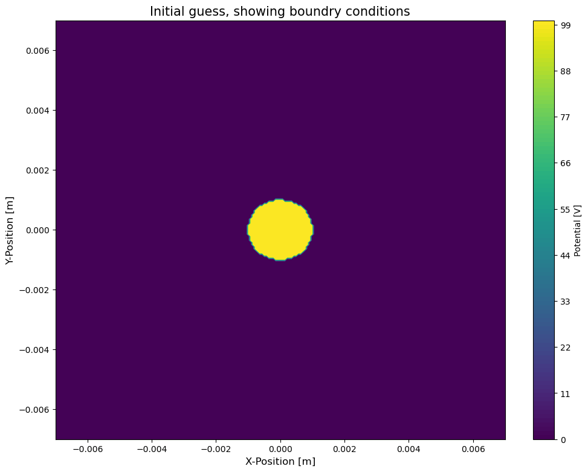

```
iterations, max difference 0 117.16746593715541
iterations, max difference 100 0.37799622236888525
iterations, max difference 200 0.017634061706115034
iterations, max difference 300 0.0015407452850446646
iterations, max difference 400 0.0001304439404705704
iterations, max difference 500 1.0914264297667842e-05
iterations, max difference 600 9.09080998923173e-07
iterations, max difference 700 7.558753978287314e-08
n iterations =  783
maximum difference =  9.82862857767941e-09
```

```python
# Your code here...
import numpy as np
import matplotlib.pyplot as plt

#set up parameters
s = .5 #scale dimensions [m]x[m]
n = 100 #grid points

#Set up x and y dimension arrays
x = np.linspace(-0.007, 0.007, (2*n + 1))
y = np.linspace(-0.007, 0.007, (2*n + 1))

def configure_inner_shell(x,y):
    inner_x = []
    inner_y = []
    for i in range(0,(2*n + 1)):
        for j in range(0,(2*n + 1)):
            x_IND = x[i]
            y_IND = y[j]
            radius = np.sqrt(x_IND**2 + y_IND**2)
            if radius <= 0.001:
                inner_x.append(i)
                inner_y.append(j)

    return inner_x, inner_y

def configure_outer_shell(x,y):
    outer_x = []
    outer_y = []
    for i in range(0,(2*n + 1)):
        for j in range(0, (2*n + 1)):
            x_IND = x[i]
            y_IND = y[j]
            radius = np.sqrt(x_IND**2 + y_IND**2)
            if radius >= 0.006 and radius <= 0.007:
                outer_x.append(i)
                outer_y.append(j)

    return outer_x, outer_y

inner_x, inner_y = configure_inner_shell(x,y)
outer_x, outer_y = configure_outer_shell(x,y)

X,Y = np.meshgrid(x,y)

N_max = 2500 # max number of iterations for relaxion method
delta = 1e-8 #max difference between iterations for iterations to stop
w = .92 #overrelaxation weighting

def boundary(p):

    #logical array if point is on "boundary"
    on_b = np.copy(p)
    on_b[:,:]=False
    max_inner_x = len(inner_x) - 1

    for i in range(0,max_inner_x):
        p[inner_x[i],inner_y[i]] = 100
        on_b[inner_x[i],inner_y[i]] = True

    max_outer_x = len(outer_x) - 1

    for j in range(0,max_outer_x):
        p[outer_x[j],outer_y[j]] = 0
        on_b[outer_x[j],outer_y[j]] = True



    return p,on_b

# initialize some arrays for iterations
p_init = np.zeros(((2*n + 1),(2*n + 1))) #set up size inital guess array
p_1 = 25*np.ones(((2*n + 1),(2*n + 1))) #last iteration for potential (utility array)

p, on_boundry = boundary(p_init)

#plot intial guess (and shows boundry conditions)
plt.figure(figsize=(12,9))
plt.contourf(X,Y,p,100)
plt.colorbar(label='Potential [V]')
plt.title('Initial guess, showing boundry conditions',fontsize=15)

plt.xlabel('X-Position [m]',fontsize=12)
plt.ylabel('Y-Position [m]',fontsize=12)
plt.show()


diff = 1000. #initialize max diff to large number for first test in while loop

i = 0  #iteration number
while diff>delta and i < N_max:  #iterate until change<delta or N_max

    for j in range(0, (2*n)):   #row=j=y
        for k in range(0, (2*n)): #column=k=x

            if on_boundry[j,k] == False:
                #Gauss-Seidel overrelaxation
                p[j,k] = (1+w)*(p[j-1,k]+p[j+1,k]+p[j,k-1]+p[j,k+1])/4-w*p[j,k]


    #calculate the maximum of the delta from this iteration-last
    d = np.abs((p_1-p))  #array of changes between iterations
    ind = np.unravel_index(np.argmax(d),d.shape) #array index of max difference
    diff = d[ind]   #max difference of array between iterations

    p_1 = np.copy(p)  #copy current iteration to utility array to calculate differecne next iteration

    if i%100 == 0:
        print('iterations, max difference',i,diff)
    i += 1

print('n iterations = ',i)
print('maximum difference = ',diff)
```

Part b: (5 points)

- Plot the equipotential contours using 'contourf' and showing a colorbar
- Calculate (using numpy gradient) and Plot (using matplotlib quiver) the Electric field $\vec{E}$
- You may want to skip every some number of points for quiver...

where,

$\vec{E} = -\nabla \phi = -\left(\frac{\partial \phi(x,y)}{\partial x }\hat{x}+\frac{\partial \phi(x,y)}{\partial y }\hat{y}\right)$

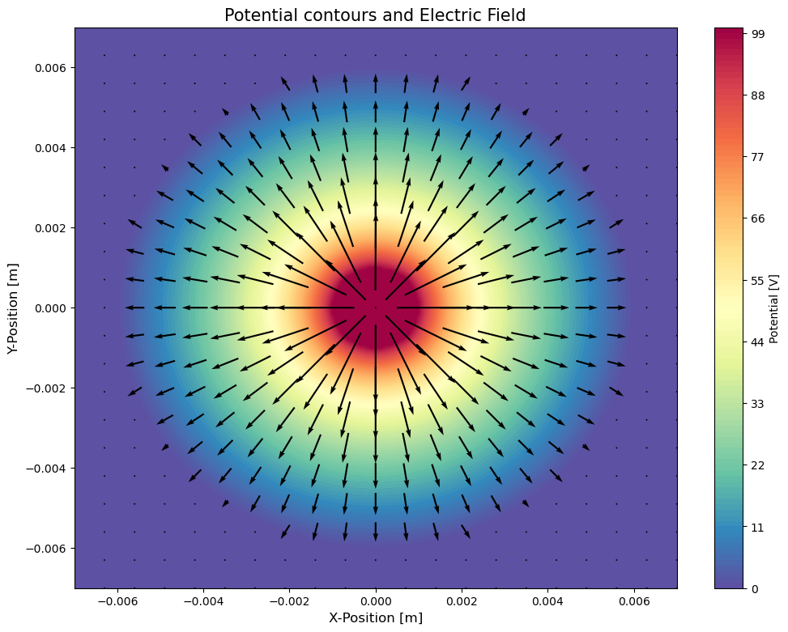

```python
# Your code here...
# plot solution for potential and gradients
plt.figure(figsize=(12,9))
plt.contourf(X,Y,p,100,cmap='Spectral_r')
plt.colorbar(label='Potential [V]')
plt.title('Potential contours and Electric Field',fontsize=15)
plt.xlabel('X-Position [m]',fontsize=12)
plt.ylabel('Y-Position [m]',fontsize=12)
E_y,E_x = np.gradient(p) #get the gradient of potential E=-grad(p)
skip=np.int_(10) #number of points to skip in plotting gradient
plt.quiver(X[::skip,::skip],Y[::skip,::skip],
           -E_x[::skip,::skip],-E_y[::skip,::skip],pivot='mid') #plot E field

plt.show()
```

```python
E_x = E_x[100]
E_x = E_x[100:]
# maxy = []
# for i in E_x:

#     maxy.append(np.max(i))

# print(np.max(maxy))
```

Part c: (5 points)

In this part we are going to examine the accuracy of the solution.

This problem has a simple analytic solution. Due to the nature of the cylindrical symmetry we can use Gauss' Law to calculate the Electric field, which is radial only, and the work-energy theorem to calculate the potential that is only a function of the radius $r$.

The solutions are:

for $a < r < b$

$\large \phi = \phi(r) = V0 \, \frac{log(r/b)}{log(a/b)}$

$\large \vec{E}= \frac{V0}{r} \frac{\hat{r}}{-log(a/b)}$

for $r \leq a$

$\phi = V0$ and $\vec{E}=0$

for $r \geq b$

$\phi = 0$ and $\vec{E}=0$

Since there is radial symmetry we will compare the numeric solution to the analytic solution along the positive x-axis only.

1) Figure 1: Plot the two solutions for the potential $\phi$ vs x for $0\leq x \leq 0.007$ 2) Figure 2: Make a plot with 2 subplots a) both potentials $\phi$ and b) difference in potentials vs x for $a <x < b$ 3) Figure 3: Make a plot with 2 subplots a) both $|\vec{E}|$ and b) difference in $|\vec{E}|$ vs x for $a <x < b$

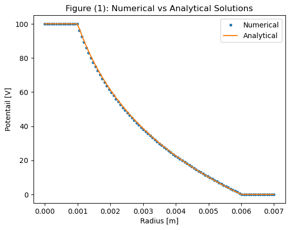

```python
# Your code here...

# Figure 1
x = np.linspace(0,0.007, n + 1)
a = 0.001
b = 0.006


phi_x_num = p[100]
phi_x_num = phi_x_num[100:]

phi_x_anl = []
for i in x:
    if i <= a:
        phi_x_anl.append(100)
    if i > a and i < b:
        phi_x_anl.append(100 * (np.log(i/b)/np.log(a/b)))
    if i >= b:
        phi_x_anl.append(0)

plt.plot(x, phi_x_num,'.', label="Numerical")
plt.plot(x, phi_x_anl, '-', label="Analytical")
plt.legend()
plt.xlabel('Radius [m]')
plt.ylabel('Potentail [V]')
plt.title('Figure (1): Numerical vs Analytical Solutions')
```

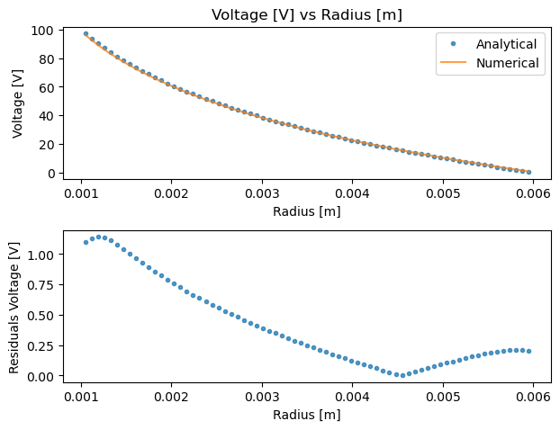

```python
fig, axs = plt.subplots(2,1)

fig.tight_layout(pad=2.0)

x_adjust = []
for i in x:
    if i > a and i < b:
        x_adjust.append(i)

phi_x_num_adjust = []
for i in phi_x_num:
    if i < 100 and i > 0:
        phi_x_num_adjust.append(i)

phi_x_anl_adjust = []
for i in x:
    if i > a and i < b:
        phi_x_anl_adjust.append(100 * (np.log(i/b)/np.log(a/b)))

phi_x_diff = []
i = 0
for j in phi_x_num_adjust:
    phi_x_diff.append(np.abs(j - phi_x_anl_adjust[i]))
    i += 1



axs[0].plot(x_adjust,phi_x_anl_adjust,'.',label='Analytical', alpha=0.75)
axs[0].plot(x_adjust,phi_x_num_adjust,'-',label='Numerical', alpha=0.75)
axs[0].legend()
axs[0].set_title('Voltage [V] vs Radius [m]')
axs[0].set_xlabel('Radius [m]')
axs[0].set_ylabel('Voltage [V]')


axs[1].plot(x_adjust,phi_x_diff,'.',label='cell', alpha=0.75)
axs[0].set_title('Voltage [V] vs Radius [m]')
axs[1].set_xlabel('Radius [m]')
axs[1].set_ylabel('Residuals Voltage [V]')
```

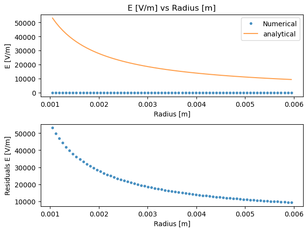

```python
fig, axs = plt.subplots(2,1)

fig.tight_layout(pad=2.0)

x_adjust = []
for i in x:
    if i > a and i < b:
        x_adjust.append(i)

phi_x_num_adjust = []
for i in E_x:
    if i < 0:
        phi_x_num_adjust.append(np.abs(i))

phi_x_num_adjust_1 = []
for i in phi_x_num_adjust:
    if i == np.max(phi_x_num_adjust):
        continue
    else:
        phi_x_num_adjust_1.append(i)

phi_x_num_adjust_2 = []
for i in phi_x_num_adjust_1:
    if i == np.max(phi_x_num_adjust_1):
        continue
    else:
        phi_x_num_adjust_2.append(i)


phi_x_anl_adjust = []
r_norm = np.linalg.norm(x)
for i in x:
    if i > a and i < b:
        phi_x_anl_adjust.append(np.abs((100/i) * (1/(-np.log(a/b)))))

phi_x_diff = []
i = 0
for j in phi_x_num_adjust_2:
    phi_x_diff.append(np.abs(j - phi_x_anl_adjust[i]))
    i += 1



# axs[0].plot(x_adjust,E_x,'.',label='Analytical', alpha=0.75)
axs[0].plot(x_adjust,phi_x_num_adjust_2,'.',label='Numerical', alpha=0.75)
axs[0].plot(x_adjust,phi_x_anl_adjust,'-',label='analytical', alpha=0.75)
axs[0].legend()
axs[0].set_title('E [V/m] vs Radius [m]')
axs[0].set_xlabel('Radius [m]')
axs[0].set_ylabel('E [V/m]')


axs[1].plot(x_adjust,phi_x_diff,'.',label='cell', alpha=0.75)
# axs[1].set_title('Voltage [V] vs Radius [m]')
axs[1].set_xlabel('Radius [m]')
axs[1].set_ylabel('Residuals E [V/m]')
```

Observations and Summary: I have to say I have absolutely no idea why the $ \textbf{E} $ was so off. It really bothered me. However, I sliced my $ \textbf{E}_x $ estimation several ways and tried to calculate the numerical solution with several methods, I just could not come to grips with this residual. But I could not figure out any other way. The 100 V0 over the radius of 0.001 is going to blow that equation up no matter way happens. Everything else was as expected.